# Tarea text mining

by Alejandro Glozman

2020-06-11

**Profesor:** *Santiago Mota*

**Análisis del texto de la Constitución Española**

Mediante técnicas de text mining y NLP se intentará analizar el texto de la Constitución Española.

# Pre procesado

## Carga de librerias

```r
# Load libraries

library(tm)
library(wordcloud)
library(dplyr)
library(ggplot2)
library(sentiment)
library(magrittr)
library(udpipe)
library(lattice)
library(igraph)
library(ggraph)
library(textrank)
```

## La Constitución española

- Primero creamos un objeto intermedio, para devolver el fichero
- Luego se extrae el texto

```r
uri  <- function(num) {return(paste0("cons_espa.pdf"))}
pdf_doc_es <- tm::readPDF(control = list(text = '-enc "UTF-8"'))(elem =
          list(uri = uri(num)), language = "es")
```

### Los metadatos

```r
pdf_doc_es$meta
```

```
##   author       : Mª Angeles Cuenca
##   datetimestamp: 2018-02-21 13:06:10
##   description  : character(0)
##   heading      : CONSTITUCIÓN ESPAÑOLA
##   id           : cons_espa.pdf
##   language     : es
##   origin       : Microsoft® Word 2013
```

### Solo el texto

Nos quedamos con el texto para seguir trabajando y lo ponemos todo en un solo documento. No aporta información tenerlo dividido en páginas

```r
pdf_texto <- content(pdf_doc_es)
pdf_texto_uno <- paste(pdf_texto, collapse = '')
```

### Se crea el corpus

```r
pdf_corpus <- VCorpus(VectorSource(pdf_texto_uno), readerControl = list(language = "es"))
inspect(pdf_corpus)
```

```
## <<VCorpus>>
## Metadata:  corpus specific: 0, document level (indexed): 0
## Content:  documents: 1
##
## [[1]]
## <<PlainTextDocument>>
## Metadata:  7
## Content:  chars: 119880
```

# ETL

## Limpiando el corpus

### Función limpiadora

- Defino una función para:
  - Eliminar stopwords
  - Eliminar números si num es true y se dejan si es false
  - Quitar acentos
  - Quitar los signos de puntuación
  - Eliminar los espacios en blanco

```r
subSpace <- content_transformer(function(x, pattern) gsub(pattern,
                                                          " ", x))
clean.text <- function(pdf_corpus,nums=TRUE){


# Pasar a minúsculas
corpus_clean <- tm_map(pdf_corpus, content_transformer(tolower))

# Quitar números
  if(nums) {
    corpus_clean <- tm_map(corpus_clean, removeNumbers)
  }
  corpus_clean <- tm_map(corpus_clean, removeWords, stopwords('es'))
  corpus_clean <- tm_map(corpus_clean, removePunctuation,
               preserve_intra_word_dashes = TRUE)


  corpus_clean <- tm_map(corpus_clean, subSpace, "«")
  corpus_clean <- tm_map(corpus_clean, subSpace, "-")
  removeAccents <- content_transformer(function(x) chartr("áéíóú", "aeiou",
                                                        x))
  corpus_clean <- tm_map(corpus_clean, removeAccents)
  corpus_clean <- tm_map(corpus_clean, stripWhitespace)
  return(corpus_clean)
}
```

### Se limpia el texto

```r
corpus_clean <- clean.text(pdf_corpus)
class(corpus_clean)
```

```
## [1] "VCorpus" "Corpus"
```

## Nube de palabras

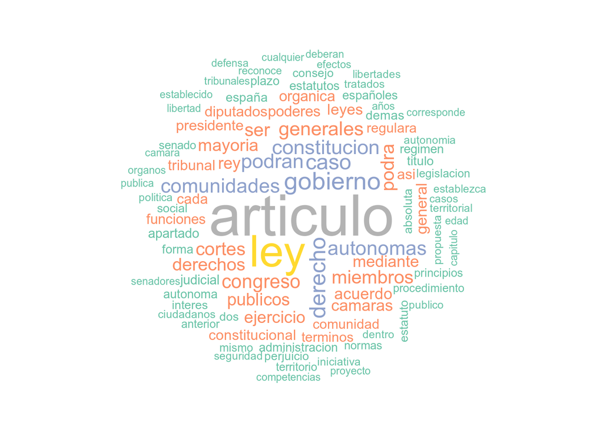

```r
set.seed(2019)
par(cex.axis=0.8)
wordcloud(corpus_clean, min.freq = 15, random.order = FALSE,
          colors = brewer.pal(8, "Set2"))
```

## Se crea el DTM

Y se inspecciona un poco

```r
# Se crea
constitucion_es_dtm <- DocumentTermMatrix(corpus_clean)

# Se inspecciona
inspect(constitucion_es_dtm)
```

```
## <<DocumentTermMatrix (documents: 1, terms: 2548)>>
## Non-/sparse entries: 2548/0
## Sparsity           : 0%
## Maximal term length: 20
## Weighting          : term frequency (tf)
## Sample             :
##     Terms
## Docs articulo autonomas caso comunidades constitucion derecho generales
##    1      229        58   67          58           61      70        56
##     Terms
## Docs gobierno ley podran
##    1       80 167     60
```

```r
# Los nombres
names(constitucion_es_dtm)
```

```
## [1] "i"        "j"        "v"        "nrow"     "ncol"     "dimnames"
```

```r
# numero de filas
constitucion_es_dtm$nrow
```

```
## [1] 1
```

```r
#Numero columnas
constitucion_es_dtm$ncol
```

```
## [1] 2548
```

```r
# Tiene lineas vacias?
constitucion_es_dtm$dimnames$Terms[x=""]
```

```
## [1] NA
```

```r
## Palabran con ñ
grep(c("ñ"), constitucion_es_dtm$dimnames$Terms)
```

```
##  [1]   18  136  138  593  594  684  685  874  875  901  902  903  904  905 1531
## [16] 1573 2237 2238 2239 2240 2241
```

```r
constitucion_es_dtm$dimnames$Terms[grep("[ñÑ]",
                    constitucion_es_dtm$dimnames$Terms)]
```

```
##  [1] "acompañados" "año"         "años"        "daño"        "daños"
##  [6] "desempeñar"  "desempeño"   "enseñanza"   "enseñas"     "españa"
## [11] "español"     "española"    "españolas"   "españoles"   "montaña"
## [16] "niños"       "señaladas"   "señalan"     "señale"      "señalen"
## [21] "señales"
```

```r
# palabras de la 100 a la 110
constitucion_es_dtm$dimnames$Terms[100:110]
```

```
##  [1] "aire"       "ajustara"   "ajusten"    "alarma"     "alava"
##  [6] "alcaldes"   "alcance"    "alcanzar"   "alcanzare"  "alcanzarse"
## [11] "alegados"
```

Lo convertimos em matriz ordenada

```r
t   <- as.matrix(constitucion_es_dtm)
# Ordenamos la matriz
v   <- sort(t[, ], decreasing = TRUE)
```

Y creamos el objeto como dataframe

```r
tdm_matriz  <- data.frame(word=names(v), freq=v)

head(tdm_matriz)
```

```
##                      word freq
## articulo         articulo  229
## ley                   ley  167
## gobierno         gobierno   80
## derecho           derecho   70
## caso                 caso   67
## constitucion constitucion   61
```

```r
class(tdm_matriz)
```

```
## [1] "data.frame"
```

```r
findFreqTerms(constitucion_es_dtm,40)
```

```
##  [1] "articulo"     "autonomas"    "camaras"      "caso"         "comunidades"
##  [6] "congreso"     "constitucion" "cortes"       "derecho"      "derechos"
## [11] "ejercicio"    "generales"    "gobierno"     "ley"          "mayoria"
## [16] "mediante"     "miembros"     "podra"        "podran"       "publicos"
## [21] "rey"          "ser"
```

## Gráfico de barras

Creamos un gráfico de barras y nos quedamos con los primeros 15 valores

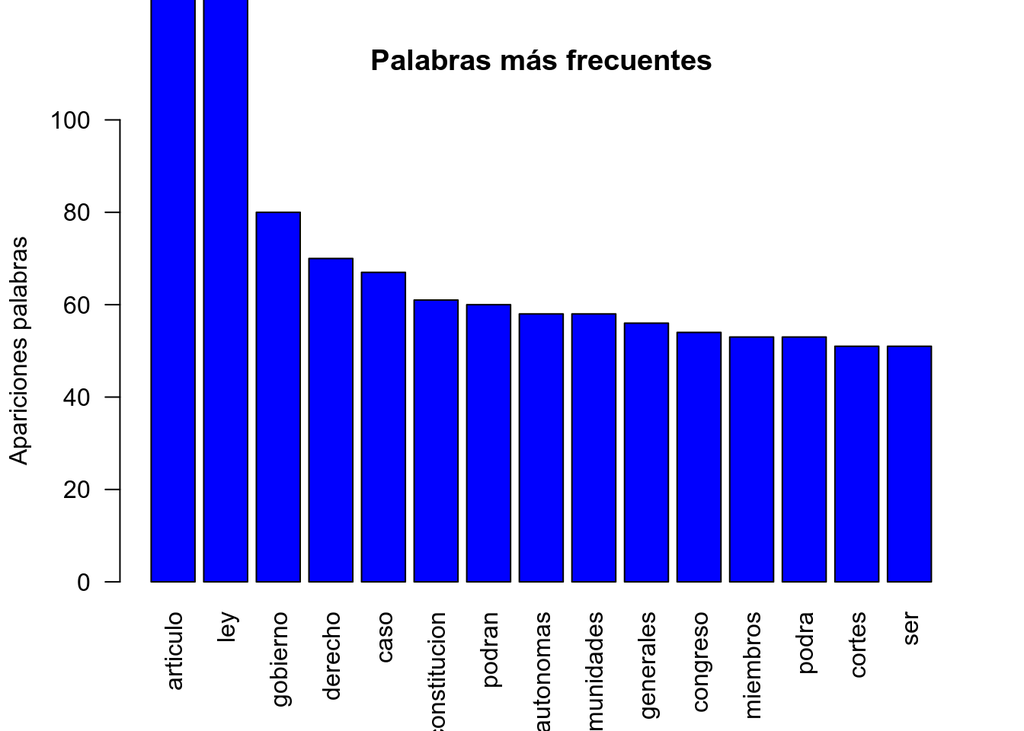

```r
barplot(tdm_matriz[1:15, ]$freq,               # Datos
        las       = 2,
        names.arg = tdm_matriz[1:15, ]$word,   # Texto en la x
        col       = "blue",                    # Color
        main      = "Palabras más frecuentes", # Título
        ylab      = "Apariciones palabras",    # Texto en la y
        ylim =     c(0, 100))                  # Limitamos el eje y a [0, 100]
```

## Importancia global

Verificamos la importancia de las palabras en relación al texto

Prepara los datos para unificar en suma las apariciones de palabras a partir de la 11º

```r
# Creamos un objeto data frame
sect           <- data.frame()

# Las primera 10 filas de tdm_matriz, con dos variables word y freq
sect           <- tdm_matriz[1:10, ]

# Convertimos la variable word a caracter (es de tipo factor)
sect$word      <- as.character(sect$word)

# Obtenemos los nombres de las filas (los 10 términos mas usados)
filas          <- rownames(sect)

# Y creamos otro valor que agrupe todo lo que no entra en los 10 primeros
filas          <- c(filas, "Resto_palabras")

# Incluimos los valores para el elemento 11 en sect. Primero el word, sect[11, 1]
sect[11, 1]    <- "Resto_palabras"

# Y un objeto, temp, que será los valores de tdm_matriz del 11 en adelante
temp           <- tdm_matriz %>% slice(11:length(tdm_matriz[, 2]))

# Y ahora la freq del resto de palabras, para eso usamos la funciona summarize
# del paquete dplyr
sect[11, 2]    <- temp %>% summarize(sum(freq))

# Por último el nombre de las filas
rownames(sect) <- filas

select
```

```
## function (.data, ...)
## {
##     UseMethod("select")
## }
## <bytecode: 0x561298e42210>
## <environment: namespace:dplyr>
```

### Gráfico importancia Global

Relación de aparición de las palabras top con el resto del texto.

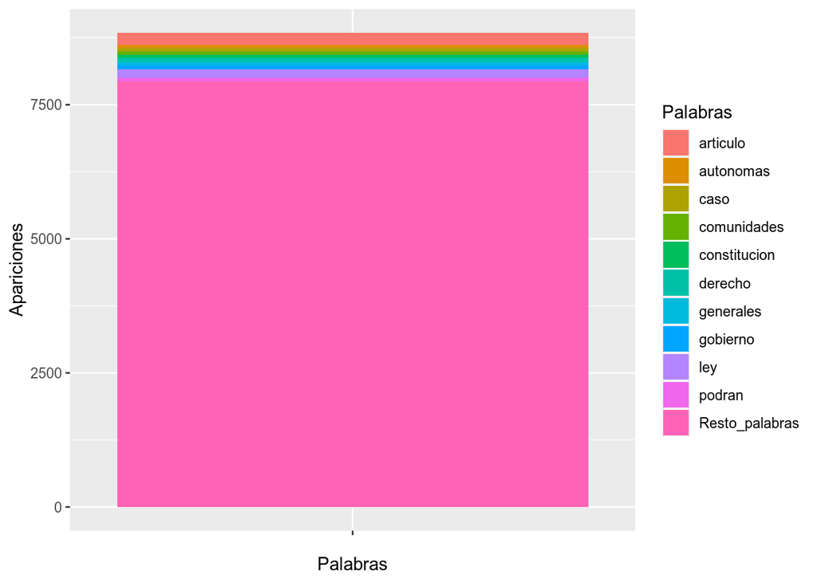

```r
sector <- ggplot(sect, aes(x = "", y = freq, fill = word)) +
  geom_bar(stat = "identity", width = 1) +
  labs(x = "Palabras", y = "Apariciones", fill = "Palabras")
sector
```

## Análisis por artículos

### Nuevo corpus

Se crea un nuevo corpus donde cada documento corresponde con un atículo de la constitucion española

```r
# dividide el texto por articulo
es <- strsplit(pdf_texto_uno,split="Artículo \\d{1,3}\n")

# se quita todo el final de la constitucion que no sea el ultimo articulo
es[[1]][170] <- gsub("([^.]+)DISPOSICIONES ADICIONALES.*", "\\1", es[[1]][170])

# Eliminamos el primer documento que corresponde a todo el texto que es anterior
#al primer articulo de la constitucion
# ahora cada articulo esta en su numero de vector coincidente con el numero sde articulo
es[[1]] <- es[[1]][-1]

# seguimos depurando para quitar los titulos de las diferentes secciones para
# analizar unicamente los articulos
es[[1]][9] <- gsub("([^.]+)TÍTULO I.*", "\\1", es[[1]][9])
es[[1]][10] <- gsub("([^.]+)CAPÍTULO PRIMERO.*", "\\1", es[[1]][10])
es[[1]][13] <- gsub("([^.]+)\\(Este artículo incluye.*", "\\1", es[[1]][13])
es[[1]][14] <- gsub("([^.]+)SECCIÓN 1.*", "\\1", es[[1]][14])
es[[1]][29] <- gsub("([^.]+)SECCIÓN 2.*", "\\1", es[[1]][29])
es[[1]][38] <- gsub("([^.]+)CAPITULO TERCERO.*", "\\1", es[[1]][38])
es[[1]][52] <- gsub("([^.]+)CAPÍTULO CUARTO.*", "\\1", es[[1]][52])
es[[1]][54] <- gsub("([^.]+)CAPITULO QUINTO.*", "\\1", es[[1]][54])
es[[1]][55] <- gsub("([^.]+)TITULO II.*", "\\1", es[[1]][55])
es[[1]][65] <- gsub("([^.]+)TITULO III.*", "\\1", es[[1]][65])
es[[1]][92] <- gsub("([^.]+)CAPITULO TERCERO.*", "\\1", es[[1]][92])
es[[1]][96] <- gsub("([^.]+)TITULO IV.*", "\\1", es[[1]][96])
es[[1]][107] <- gsub("([^.]+)TITULO V.*", "\\1", es[[1]][107])
es[[1]][116] <- gsub("([^.]+)TITULO VI.*", "\\1", es[[1]][116])
es[[1]][127] <- gsub("([^.]+)TÍTULO VII.*", "\\1", es[[1]][127])
es[[1]][135] <- gsub(".*septiembre de 2011\\)\\n([^.]+)", "\\1", es[[1]][135])
es[[1]][136] <- gsub("([^.]+)TÍTULO VIII.*", "\\1", es[[1]][136])
es[[1]][139] <- gsub("([^.]+)CAPÍTULO SEGUNDO.*", "\\1", es[[1]][139])
es[[1]][142] <- gsub("([^.]+)CAPÍTULO TERCERO.*", "\\1", es[[1]][142])
es[[1]][158] <- gsub("([^.]+)TITULO IX.*", "\\1", es[[1]][158])
es[[1]][165] <- gsub("([^.]+)TITULO X.*", "\\1", es[[1]][165])




# se quitan los numeros de subarticulos
es[[1]] <- gsub("\\d\\.", "", es[[1]])



# se quitan las subsecciones de articulos
es[[1]] <- gsub(" {2,}[a-z]{1}\\)", "", es[[1]])


# Quitamos espacion en blanco de principio y final
es[[1]] <- gsub("^\\s+|\\s+$", "", es[[1]])
```

De la Constitución española nos hemos quedado únicamente con los contenidos de los artículos y ya se tiene cada artículo separado en su correspondiente número de un vector

### Nube de palabras

**ETL** Se ha quitado todo lo que no corresponda al contenido de los artículos. Se vuelve a limpiar el texto, esta vez sin quitar números y se ve como queda la nube de palabras

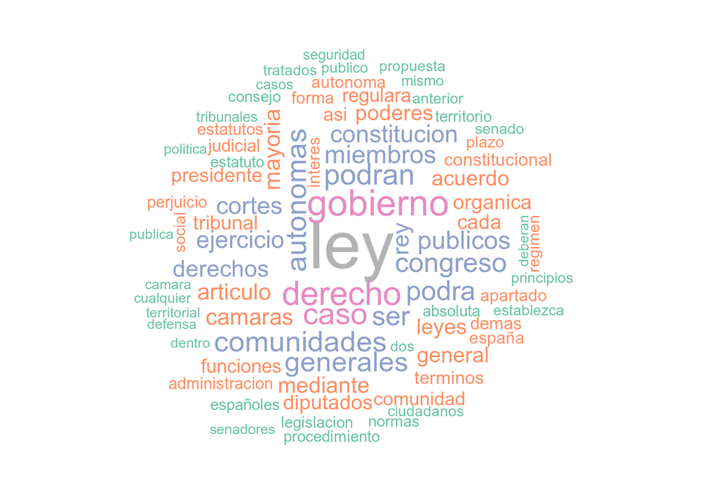

```r
pdf_corpus_es <- VCorpus(VectorSource(es), readerControl = list(language = "es"))
#pdf_corpus_es <- tm_map(pdf_corpus_es, stemDocument, language="spanish")


corpus_clean_es <- clean.text(pdf_corpus_es,nums = FALSE)

# Nube de palabras
set.seed(2019)
par(cex.axis=0.8)
wordcloud(corpus_clean_es, min.freq = 15, random.order = FALSE,
          colors = brewer.pal(8, "Set2"))
```

# Análisis

## DTM

Se crea el DTM

```r
constitucion_esArt_dtm <- DocumentTermMatrix(corpus_clean_es)
```

```r
constitucion_esArt_dtm$nrow
```

```
## [1] 1
```

El nuevo DTM tiene 2401 palabras.

### Palabras con ñ

```r
constitucion_esArt_dtm$dimnames$Terms[grep("[ñÑ]",
                                        constitucion_esArt_dtm$dimnames$Terms)]
```

```
##  [1] "acompañados" "año"         "años"        "daño"        "daños"
##  [6] "desempeñar"  "desempeño"   "enseñanza"   "enseñas"     "españa"
## [11] "español"     "española"    "españolas"   "españoles"   "montaña"
## [16] "niños"       "señaladas"   "señale"      "señalen"     "señales"
```

## Términos frecuentes

Lo convertimos em matriz y miramos los términos más frecuentes.

```r
t   <- as.matrix(constitucion_esArt_dtm)

length(t)
```

```
## [1] 2401
```

```r
# Ordenamos la matriz
v   <- sort(t[, ], decreasing = TRUE)

# Y creamos el objeto como dataframe
tdm_matriz  <- data.frame(word=names(v), freq=v)

findFreqTerms(constitucion_esArt_dtm,40)
```

```
##  [1] "autonomas"    "caso"         "comunidades"  "congreso"     "constitucion"
##  [6] "cortes"       "derecho"      "derechos"     "ejercicio"    "generales"
## [11] "gobierno"     "ley"          "miembros"     "podra"        "podran"
## [16] "publicos"     "rey"          "ser"
```

### Gráfico de barras

Creamos un gráfico de barras y nos quedamos con los primeros 15 valores

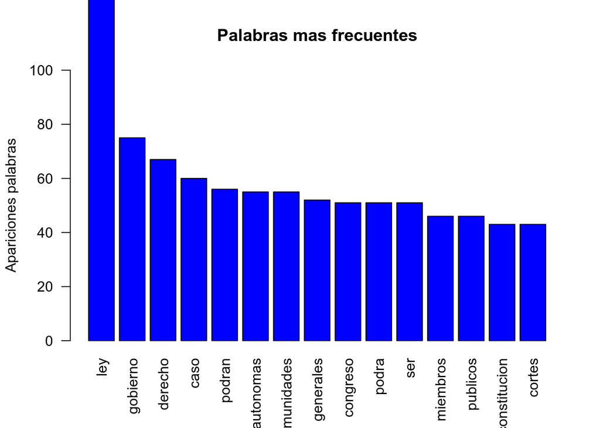

```r
barplot(tdm_matriz[1:15, ]$freq,               # Datos
        las       = 2,
        names.arg = tdm_matriz[1:15, ]$word,   # Texto en la x
        col       = "blue",                    # Color
        main      = "Palabras mas frecuentes", # Título
        ylab      = "Apariciones palabras",    # Texto en la y
        ylim =     c(0, 100))                  # Limitamos el eje y a [0, 100]
```

### Importancia global

Importancia de los terminos más frecuentes en relación a todo el texto mediante un gráfico

```r
# Prepara los datos para unificar en suma las apariciones de palabras
# a partir de la 11º

# Creamos un objeto data frame
sect           <- data.frame()

# Las primera 10 filas de tdm_matriz, con dos variables word y freq
sect           <- tdm_matriz[1:10, ]

# Convertimos la variable word a caracter (es de tipo factor)
sect$word      <- as.character(sect$word)

# Obtenemos los nombres de las filas (los 10 términos mas usados)
filas          <- rownames(sect)

# Y creamos otro valor que agrupe todo lo que no entra en los 10 primeros
filas          <- c(filas, "Resto_palabras")

# Incluimos los valores para el elemento 11 en sect. Primero el word, sect[11, 1]
sect[11, 1]    <- "Resto_palabras"

# Y un objeto, temp, que será los valores de tdm_matriz del 11 en adelante
temp           <- tdm_matriz %>% slice(11:length(tdm_matriz[, 2]))

# Y ahora la freq del resto de palabras, para eso usamos la funciona summarize
# del paquete dplyr
sect[11, 2]    <- temp %>% summarize(sum(freq))

# Por último el nombre de las filas
rownames(sect) <- filas

select
```

```
## function (.data, ...)
## {
##     UseMethod("select")
## }
## <bytecode: 0x561298e42210>
## <environment: namespace:dplyr>
```

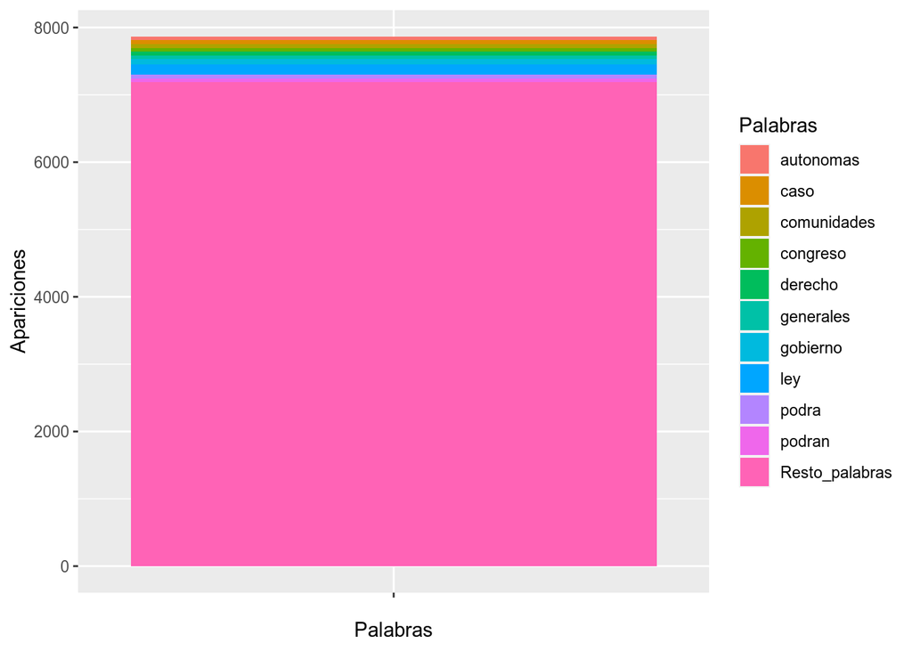

```r
# Y creo un grafico que llamo sector
sector <- ggplot(sect, aes(x = "", y = freq, fill = word)) +
  geom_bar(stat = "identity", width = 1) +
  labs(x = "Palabras", y = "Apariciones", fill = "Palabras")
sector
```

## Análisis de sentimientos

**Análisis de sentimientos de la Constitución** Basado en el siguiente repositorio de github: https://github.com/dlizcano/tuit_sentimiento

```r
pos.words <- scan("sentimiento_positivas.txt", character(), quote = "")
neg.words <- scan("sentimiento_negativas.txt", character(), quote = "")
```

```r
source("classify_polarity.R")
source("classify_emotion.R")
source("create_matrix.R")


score.sentiment = function(sentences, pos.words, neg.words, .progress='none')
{
  require(plyr)
  require(stringr)
  # we got a vector of sentences. plyr will handle a list
  # or a vector as an "l" for us
  # we want a simple array ("a") of scores back, so we use
  # "l" + "a" + "ply" = "laply":
  scores = laply(sentences, function(sentence, pos.words, neg.words) {
    # clean up sentences with R's regex-driven global substitute, gsub():
    sentence = gsub('[[:punct:]]', '', sentence)
    sentence = gsub('[[:cntrl:]]', '', sentence)
    sentence = gsub('\\d+', '', sentence)
    # and convert to lower case:
    sentence = tolower(sentence)
    # split into words. str_split is in the stringr package
    word.list = str_split(sentence, '\\s+')
    # sometimes a list() is one level of hierarchy too much
    words = unlist(word.list)
    # compare our words to the dictionaries of positive & negative terms
    pos.matches = match(words, pos.words)
    neg.matches = match(words, neg.words)
    # match() returns the position of the matched term or NA
    # we just want a TRUE/FALSE:
    pos.matches = !is.na(pos.matches)
    neg.matches = !is.na(neg.matches)
    # and conveniently enough, TRUE/FALSE will be treated as 1/0 by sum():
    score = sum(pos.matches) - sum(neg.matches)
    return(score)
  }, pos.words, neg.words, .progress=.progress )
  scores.df = data.frame(score=scores, text=sentences)
  return(scores.df)
}
```

### Emoción de artículos

Clasificamos por emoción cada artículo de la Constitución

```r
class_emo = classify_emotion(es[[1]], algorithm="bayes", prior=1.0)
class_pol = classify_polarity(es[[1]], algorithm="bayes")
```

```r
head(class_emo)
```

```
##      Enojo              Repulsion         Miedo              Alegria
## [1,] "1.67332176906384" "2.2764081257056" "2.26688424419435" "1.11445420413377"
## [2,] "1.67332176906384" "2.2764081257056" "2.26688424419435" "7.61874237767041"
## [3,] "1.67332176906384" "2.2764081257056" "2.26688424419435" "7.61874237767041"
## [4,] "1.67332176906384" "2.2764081257056" "7.61874237767041" "1.11445420413377"
## [5,] "1.67332176906384" "2.2764081257056" "2.26688424419435" "1.11445420413377"
## [6,] "1.67332176906384" "2.2764081257056" "2.26688424419435" "7.61874237767041"
##      Tristeza           Sorpresa          BEST_FIT
## [1,] "1.65003481768505" "2.4539564037469" "Sorpresa"
## [2,] "1.65003481768505" "2.4539564037469" "Alegria"
## [3,] "1.65003481768505" "2.4539564037469" "Alegria"
## [4,] "1.65003481768505" "2.4539564037469" "Miedo"
## [5,] "1.65003481768505" "2.4539564037469" "Sorpresa"
## [6,] "7.61874237767041" "2.4539564037469" "Alegria"
```

**La emoción de los primeros 20 artículos**

```r
emotion = class_emo[,7]
emotion[1:20]
```

```
##  [1] "Sorpresa" "Alegria"  "Alegria"  "Miedo"    "Sorpresa" "Alegria"
##  [7] "Alegria"  "Sorpresa" "Sorpresa" "Alegria"  "Tristeza" "Sorpresa"
## [13] "Alegria"  "Sorpresa" "Tristeza" "Enojo"    "Alegria"  "Alegria"
## [19] "Alegria"  "Alegria"
```

**Polaridad de los primeros 20 artículos**

```r
polarity = class_pol[,4]
polarity[1:20]
```

```
##  [1] "neutral"  "neutral"  "neutral"  "negative" "neutral"  "positive"
##  [7] "neutral"  "neutral"  "positive" "positive" "negative" "positive"
## [13] "positive" "positive" "negative" "neutral"  "neutral"  "positive"
## [19] "negative" "positive"
```

```r
# Creamos data frame con los resultados para poder graficar
sent_df = data.frame(text=es[[1]], emotion=emotion,
                     polarity=polarity, stringsAsFactors=FALSE)
# sort data frame
sent_df = within(sent_df,
             emotion <- factor(emotion, levels=names(sort(table(emotion), decreasing=TRUE))))
```

### Gráfico de emociones

Se grafica el resultado del análisis de emociones de los artículos de la Constitución española

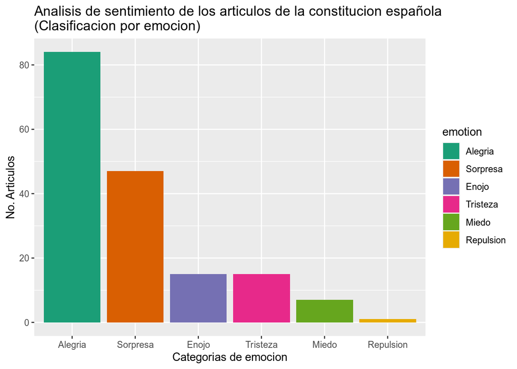

```r
# plot distribution of emotions
ggplot(sent_df, aes(x=emotion)) +
  geom_bar(aes(y=..count.., fill=emotion)) +
  scale_fill_brewer(palette="Dark2") +
  labs(x="Categorias de emocion", y="No. Articulos",
       title = "Analisis de sentimiento de los articulos de la constitucion española\n(Clasificacion por emocion)",
       plot.title = element_text(size=12))
```

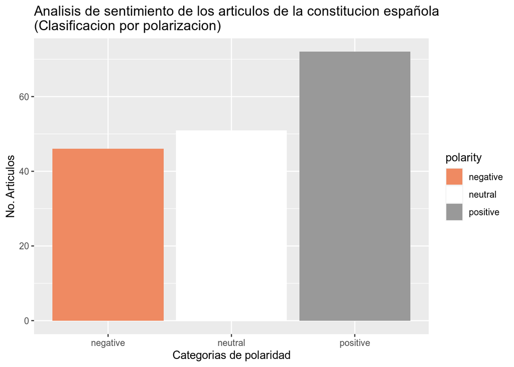

```r
# plot distribution of polarity
ggplot(sent_df, aes(x=polarity)) +
  geom_bar(aes(y=..count.., fill=polarity)) +
  scale_fill_brewer(palette="RdGy") +
  labs(x="Categorias de polaridad", y="No. Articulos",
       title = "Analisis de sentimiento de los articulos de la constitucion española\n(Clasificacion por polarizacion)",
       plot.title = element_text(size=12))
```

## NLP

**Procesamiento de lenguajes naturales**

### Pre procesado

```r
data(brussels_reviews)

articulos <- pdf_corpus_es

articulos_clean <- tm_map(articulos, content_transformer(tolower))
articulos_clean <- tm_map(articulos_clean, stripWhitespace)
articulos_clean <- tm_map(articulos_clean, subSpace, "«")
articulos_clean <- tm_map(articulos_clean, subSpace, "-")

# articulos_clean <- tm_map(articulos_clean, removeWords, stopwords('es'))
articulos_clean <- tm_map(articulos_clean, removePunctuation,
               preserve_intra_word_dashes = TRUE)
articulos_clean <- tm_map(articulos_clean, stripWhitespace)
ud_model <- udpipe_download_model(language = "spanish")
```

```
## Visit https://github.com/jwijffels/udpipe.models.ud.2.4 for model license details
```

```r
ud_model <- udpipe_load_model(ud_model$file_model)
summary(ud_model)
```

```
##       Length Class  Mode
## file  1      -none- character
## model 1      -none- externalptr
```

```r
pdf_corpus_es[[1]][1]$content[1]
```

```
## [1] "España se constituye en un Estado social y democrático de Derecho, que\npropugna como valores superiores de su ordenamiento jurídico la libertad, la justicia, la\nigualdad y el pluralismo político.\n         La soberanía nacional reside en el pueblo español, del que emanan los poderes\ndel E…
```

```r
articulos_clean[[1]][1]$content[1]
```

```
## [1] "españa se constituye en un estado social y democrático de derecho que propugna como valores superiores de su ordenamiento jurídico la libertad la justicia la igualdad y el pluralismo político la soberanía nacional reside en el pueblo español del que emanan los poderes del estado la forma pol…
```

```r
x <- udpipe_annotate(ud_model, x = articulos_clean[[1]][1]$content)
x <- as.data.frame(x)

str(ud_model$file_model)
```

```r
length(x$upos %in% c("NOUN", "ADJ"))
```

```
## [1] 16352
```

```r
re <- x$upos %in% c("NOUN", "ADJ")
```

### Resultados

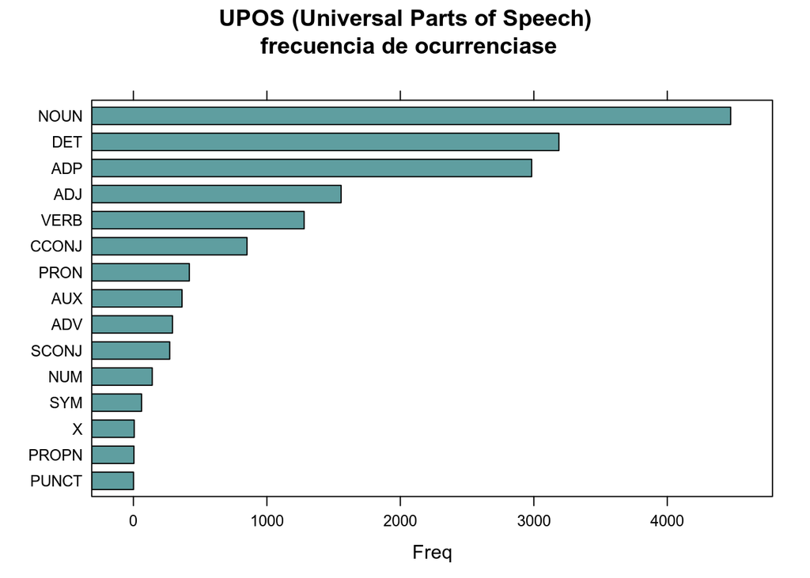

```r
stats <- txt_freq(x$upos)
stats$key <- factor(stats$key, levels = rev(stats$key))
barchart(key ~ freq, data = stats, col = "cadetblue",
         main = "UPOS (Universal Parts of Speech)\n frecuencia de ocurrenciase",
         xlab = "Freq")
```

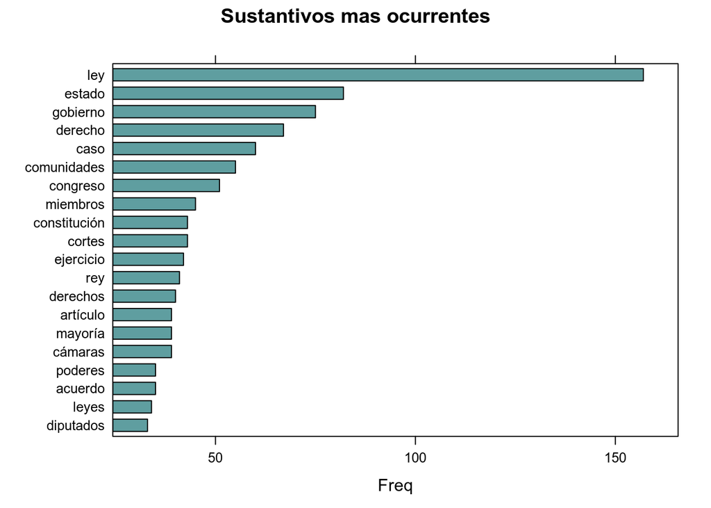

```r
## NOUNS
stats <- subset(x, upos %in% c("NOUN"))
stats <- txt_freq(stats$token)
stats$key <- factor(stats$key, levels = rev(stats$key))
barchart(key ~ freq, data = head(stats, 20), col = "cadetblue",
         main = "Sustantivos mas ocurrentes", xlab = "Freq")
```

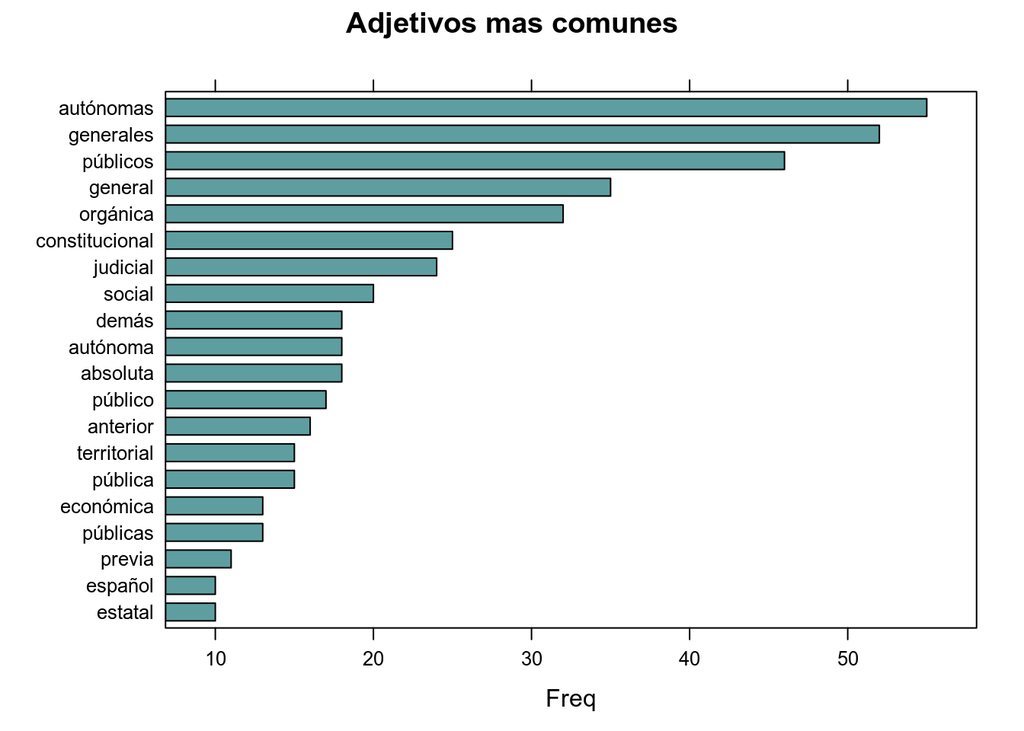

```r
## ADJECTIVES
stats <- subset(x, upos %in% c("ADJ"))
stats <- txt_freq(stats$token)
stats$key <- factor(stats$key, levels = rev(stats$key))
barchart(key ~ freq, data = head(stats, 20), col = "cadetblue",
         main = "Adjetivos mas comunes", xlab = "Freq")
```

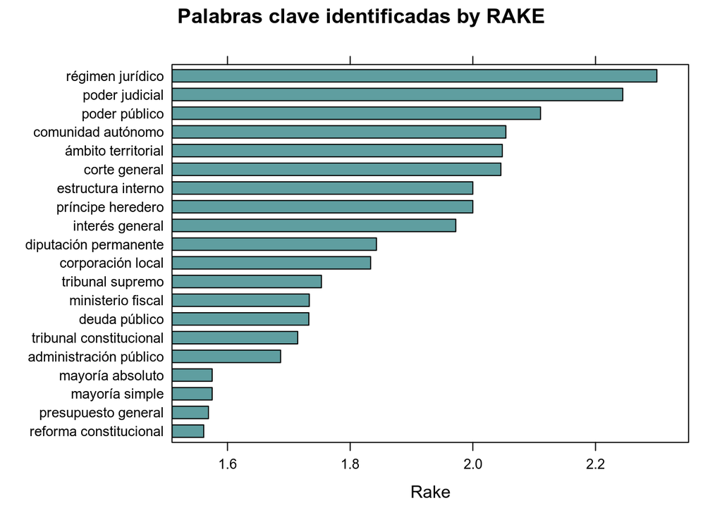

```r
## Using RAKE
stats <- keywords_rake(x = x, term = "lemma", group = "doc_id",
                       relevant = x$upos %in% c("NOUN", "ADJ"))
stats$key <- factor(stats$keyword, levels = rev(stats$keyword))
barchart(key ~ rake, data = head(subset(stats, freq > 3), 20), col = "cadetblue",
         main = "Palabras clave identificadas by RAKE",
         xlab = "Rake")
```

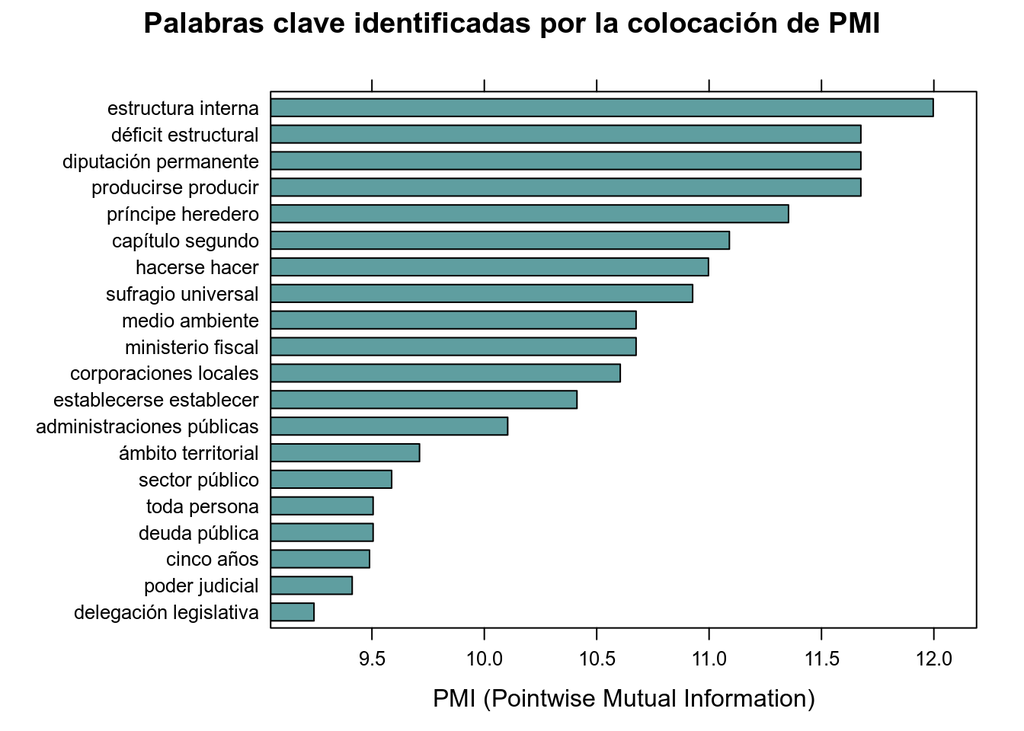

```r
## Using Pointwise Mutual Information Collocations
x$word <- tolower(x$token)
stats <- keywords_collocation(x = x, term = "word", group = "doc_id")
stats$key <- factor(stats$keyword, levels = rev(stats$keyword))
barchart(key ~ pmi, data = head(subset(stats, freq > 3), 20), col = "cadetblue",
         main = "Palabras clave identificadas por la colocación de PMI",
         xlab = "PMI (Pointwise Mutual Information)")
```

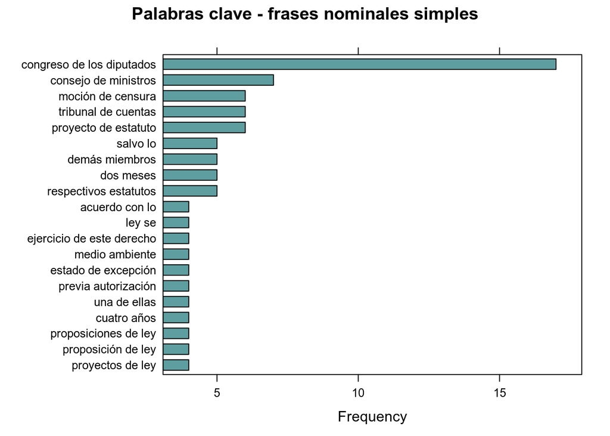

```r
## Using a sequence of POS tags (noun phrases / verb phrases)
x$phrase_tag <- as_phrasemachine(x$upos, type = "upos")
stats <- keywords_phrases(x = x$phrase_tag, term = tolower(x$token),
                          pattern = "(A|N)*N(P+D*(A|N)*N)*",
                          is_regex = TRUE, detailed = FALSE)
stats <- subset(stats, ngram > 1 & freq > 3)
stats$key <- factor(stats$keyword, levels = rev(stats$keyword))
barchart(key ~ freq, data = head(stats, 20), col = "cadetblue",
         main = "Palabras clave - frases nominales simples", xlab = "Frequency")
```

```r
## ** It does not work in churn. Works in terminal **

## Collocation (words following one another)
stats <- keywords_collocation(x = x,
                             term = "token", group = c("doc_id", "paragraph_id", "sentence_id"),
                             ngram_max = 4)
```

```r
length(x$lemma)
```

```
## [1] 16352
```

```r
length(x$upos %in% c("NOUN", "ADJ"))
```

```
## [1] 16352
```

```r
## Co-occurrences: How frequent do words follow one another even if we would skip 2 words in between
stats <- cooccurrence(x = x$lemma,
                     relevant = x$upos %in% c("NOUN", "ADJ"), skipgram = 2)
```